# Info 201 Final Project

Alan Tran, Johann Ravindranathan

2024-12-12

## Introduction

Earning a college degree represents a significant investment of time and energy, not to mention money. Those considering a degree need confidence that their initial investments will translate to opportunities upon graduation. In this report we will study what this return on investment looks like.

Our sample is colleges and universities (we will collectively refer to them as colleges from here) in the Seattle region, and we will investigate what the financial impact of a degree looked like for their students. We use student loan debt as a metric for student investment into a degree, and their salaries after four years as an indication of their post-graduation success.

## Our Data

For writing this report, we consulted the US Department of Education’s College Scoreboard website at the following link:

https://collegescorecard.ed.gov/data

This page provides 3 download links. We used the “Most Recent Institution-Level Data” and the “Most Recent Data by Field of Study”.

The gathered information comes courtesy of the Integrated Postsecondary Education Data System, or IPEDS. Information on the IPEDS is available here:

https://nces.ed.gov/ipeds

Per the College Scoreboard website, “Most Recent Institution-Level Data” covers “information on institutional characteristics, enrollment, student aid, costs, and student outcomes”. We used this dataset to gather our information on student debt and salaries.

College Scoreboard describes “Most Recent Data by Field of Study” as “data at the credential level and 4-digit CIP code combination for each institution. Includes information on cumulative debt at graduation and earnings one year after graduation”. This dataset contains, among other things, information on the degrees earned by students at the colleges represented in the IPEDS.

## Outside Opinions

The subject of college costs ties in closely with the subject of student loans and student loan debt. The following article uses College Board statistics to provide a breakdown of student loan figures in a number of categories:

https://www.businessinsider.com/personal-finance/student-loans/average-student-loan-debt

One of the interesting statistics stated was connection between a student’s family income and the debt they hold post-graduation. There was a positive correlation between a student’s family income and the debt balance they held upon graduation. This indicates that high income families were taking large loans, compared to the loans taken by a low-income family. One interpretation of this could be that as family income increases, the students are willing to take on bigger financial burdens in pursuit of a degree.

The following article covers some of the challenges faced by students pursuing a degree in the United States. The data referenced in the article came courtesy of the Strada Education Foundation.

https://www.insidehighered.com/news/students/careers/2024/04/02/rating-states-work-post-college-outcomes

The article provides graphics in relation to the topics of college affordability and employer alignment, aka how well students are trained for workforce employment. The article lists Washington and California as the two most affordable states for students to study in, claiming the average student may require less than 10 hours of employment a week to pay off tuition fees. On the other hand, Washington state was given a middling score on the subject of workforce - preparation, thought it was far more alone in this classification.

A conclusion from these findings is that Washington state is a relatively easy place to study in, though the post-graduation opportunities are less certain. This can be applied to our focus on the Seattle area.

## How Does Post-Graduation Salary Vary By College?

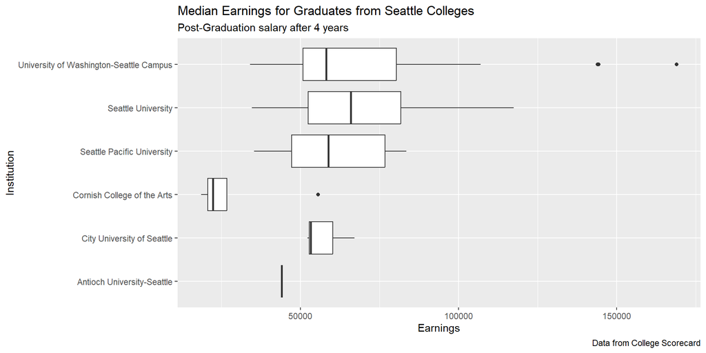

## How Does Average Post-Graduation Debt Vary By College?

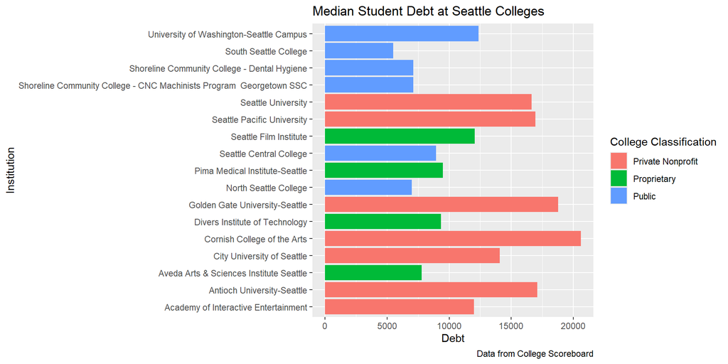

## Analyzing the Data

Data on the average earnings of students four years after graduation proved to be a limiting restraint on our data. Nonetheless, some observations can still be made using the following 6 colleges:

- Cornish College of the Arts (CCotA)
- Antioch University - Seattle (AU-Seattle)
- Seattle Pacific University (SPU)
- Seattle University (SU)
- City University of Seattle (CUoS)
- University of Washington - Seattle (UW-Seattle)

Analyzing the middle 50% of earnings by students 4 years after graduation:

- The CCotA showed earnings of around $25,000.
- AU-Seattle showed a median earning between $40,000 and $50,000.
- CUoS showed earnings from $50,000 to $60,000.
- SPU, SU, and UW-Seattle showed a range of earnings from sub-$50,000 to ~$80,000.

Comparing the debt figures for these colleges:

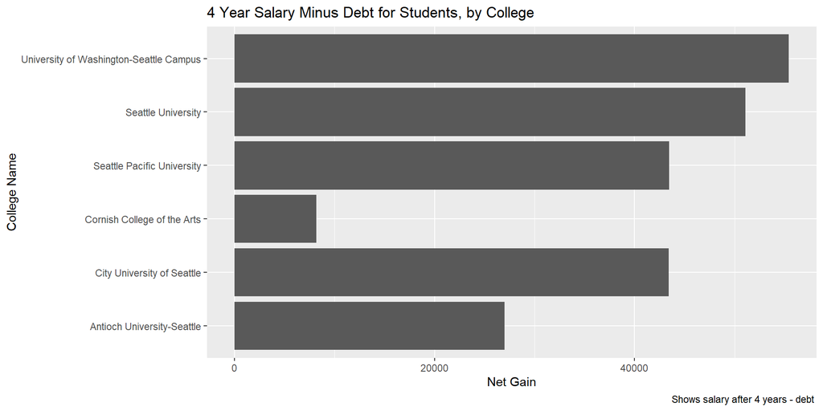